# *ScolarlyOutput*

*ScolarlyOutput* is a small R Shiny app for creating and exporting a complete plot of your academic [**Google Scholar**](https://scholar.google.com/) profile.

It only requires the full link to your Google Scholar profile (just copy it and paste it in the box), and it will create a plot with your name (as it appears on your Gsoogle Scholar profile) and two panels:

1. Citations per publication (including h- and g-index)
2. Number of publications and citations per year (including total number of citations)

Below is an example of the *ScolarlyOutput* UI showing a plot of my own profile:

[figure not shown]

ScolarlyOutput user interface

You can change an accent colour and filter publications.

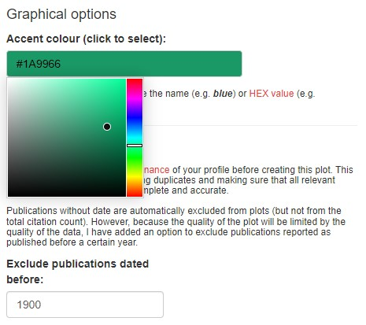

Colour picker

Once you are happy, the plot can be exported to **PNG**, **PDF**, and even **SVG** format in case you want to edit it (the downloaded file will be named `Scholar_profile.png`, only changing the file extension depending in the format you selected).

The downloaded plot (in this case, as PNG) looks like this:

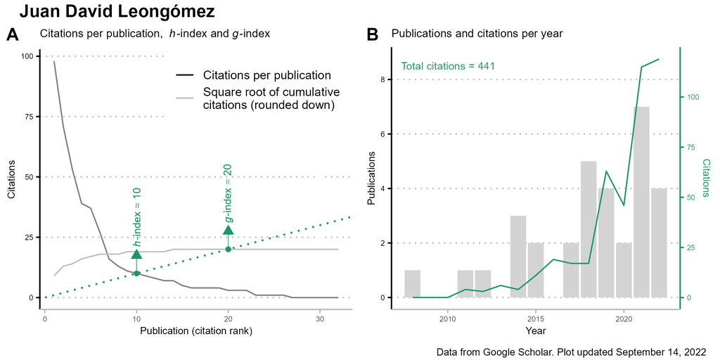

ScolarlyOutput plot example

This app uses the fantastic [`scholar`](https://cran.r-project.org/web/packages/scholar/vignettes/scholar.html) R package to extract the info from your Google Scholar profile, and then several [`tidyverse`](https://www.tidyverse.org/) packages (most notably [`ggplot2`](https://ggplot2.tidyverse.org/)) to wrangle and plot these data.

## How to run it

Sadly, the [`scholar`](https://cran.r-project.org/web/packages/scholar/vignettes/scholar.html) package cannot be run from a server like shinyapps.io, so this app must be run locally in your computer with R installed.

However, running it is very easy: you can simply run the code below in R (please note that the [`shiny`](https://shiny.rstudio.com/) package must be installed):

```r
#install.packages("shiny")
library(shiny)
runGitHub("ScolarlyOutput", "JDLeongomez")
```

Alternatively, you can always [download](https://github.com/JDLeongomez/ScolarlyOutput/archive/refs/heads/main.zip) the *ScolarlyOutput* repository, and run the [`app.R`](https://github.com/JDLeongomez/ScolarlyOutput/blob/main/app.R) file.

## Why I made this super small app

I originally wrote a script to download data from Google Scholar and make these plots for a particular version of my CV. However, several friends liked it and wanted to make plots of their own profiles (and be able to easily update them), so I decided to turn the code into a Shiny App for anyone to use.